# Optimal Treatment Analysis

## Outcome Variable

**Outcome Variable:** haz

## Predictor Variables

**Intervention Variable:** mbmi

**Adjustment Set:**

- arm
- W_mage
- W_fage
- meducyrs
- feducyrs
- single
- brthmon
- delta_W_mage
- delta_W_fage
- delta_meducyrs
- delta_feducyrs
- delta_single
- delta_brthmon

## Stratifying Variables

The analysis was stratified on these variable(s):

- agecat
- studyid
- country

## Data Summary

| agecat | studyid | country | mbmi | n_cell | n |
| --- | --- | --- | --- | --- | --- |
| Birth | ki0047075b-MAL-ED | BANGLADESH | Normal weight | 216 | 246 |
| Birth | ki0047075b-MAL-ED | BANGLADESH | Underweight | 30 | 246 |
| Birth | ki0047075b-MAL-ED | BRAZIL | Normal weight | 175 | 184 |
| Birth | ki0047075b-MAL-ED | BRAZIL | Underweight | 9 | 184 |
| Birth | ki0047075b-MAL-ED | INDIA | Normal weight | 159 | 198 |
| Birth | ki0047075b-MAL-ED | INDIA | Underweight | 39 | 198 |
| Birth | ki0047075b-MAL-ED | NEPAL | Normal weight | 172 | 172 |
| Birth | ki0047075b-MAL-ED | NEPAL | Underweight | 0 | 172 |
| Birth | ki0047075b-MAL-ED | PERU | Normal weight | 271 | 276 |
| Birth | ki0047075b-MAL-ED | PERU | Underweight | 5 | 276 |
| Birth | ki0047075b-MAL-ED | SOUTH AFRICA | Normal weight | 223 | 228 |
| Birth | ki0047075b-MAL-ED | SOUTH AFRICA | Underweight | 5 | 228 |
| Birth | ki0047075b-MAL-ED | TANZANIA, UNITED REPUBLIC OF | Normal weight | 114 | 121 |
| Birth | ki0047075b-MAL-ED | TANZANIA, UNITED REPUBLIC OF | Underweight | 7 | 121 |
| Birth | ki1000304b-SAS-CompFeed | INDIA | Normal weight | 91 | 130 |
| Birth | ki1000304b-SAS-CompFeed | INDIA | Underweight | 39 | 130 |
| Birth | ki1017093-NIH-Birth | BANGLADESH | Normal weight | 23 | 28 |
| Birth | ki1017093-NIH-Birth | BANGLADESH | Underweight | 5 | 28 |
| Birth | ki1017093c-NIH-Crypto | BANGLADESH | Normal weight | 21 | 27 |
| Birth | ki1017093c-NIH-Crypto | BANGLADESH | Underweight | 6 | 27 |
| Birth | ki1119695-PROBIT | BELARUS | Normal weight | 13200 | 13723 |
| Birth | ki1119695-PROBIT | BELARUS | Underweight | 523 | 13723 |
| Birth | ki1126311-ZVITAMBO | ZIMBABWE | Normal weight | 9124 | 9634 |
| Birth | ki1126311-ZVITAMBO | ZIMBABWE | Underweight | 510 | 9634 |
| 6 months | ki0047075b-MAL-ED | BANGLADESH | Normal weight | 209 | 241 |
| 6 months | ki0047075b-MAL-ED | BANGLADESH | Underweight | 32 | 241 |
| 6 months | ki0047075b-MAL-ED | BRAZIL | Normal weight | 199 | 208 |
| 6 months | ki0047075b-MAL-ED | BRAZIL | Underweight | 9 | 208 |
| 6 months | ki0047075b-MAL-ED | INDIA | Normal weight | 186 | 235 |
| 6 months | ki0047075b-MAL-ED | INDIA | Underweight | 49 | 235 |

[output cut: 52 more lines]

The following strata were considered:

- agecat: 24 months, studyid: ki0047075b-MAL-ED, country: BANGLADESH
- agecat: 24 months, studyid: ki0047075b-MAL-ED, country: BRAZIL
- agecat: 24 months, studyid: ki0047075b-MAL-ED, country: INDIA
- agecat: 24 months, studyid: ki0047075b-MAL-ED, country: NEPAL
- agecat: 24 months, studyid: ki0047075b-MAL-ED, country: PERU
- agecat: 24 months, studyid: ki0047075b-MAL-ED, country: SOUTH AFRICA
- agecat: 24 months, studyid: ki0047075b-MAL-ED, country: TANZANIA, UNITED REPUBLIC OF
- agecat: 24 months, studyid: ki1017093-NIH-Birth, country: BANGLADESH
- agecat: 24 months, studyid: ki1017093b-PROVIDE, country: BANGLADESH
- agecat: 24 months, studyid: ki1017093c-NIH-Crypto, country: BANGLADESH
- agecat: 24 months, studyid: ki1066203-TanzaniaChild2, country: TANZANIA, UNITED REPUBLIC OF
- agecat: 24 months, studyid: ki1119695-PROBIT, country: BELARUS
- agecat: 24 months, studyid: ki1126311-ZVITAMBO, country: ZIMBABWE
- agecat: 24 months, studyid: ki1148112-LCNI-5, country: MALAWI
- agecat: 6 months, studyid: ki0047075b-MAL-ED, country: BANGLADESH
- agecat: 6 months, studyid: ki0047075b-MAL-ED, country: BRAZIL
- agecat: 6 months, studyid: ki0047075b-MAL-ED, country: INDIA
- agecat: 6 months, studyid: ki0047075b-MAL-ED, country: NEPAL
- agecat: 6 months, studyid: ki0047075b-MAL-ED, country: PERU
- agecat: 6 months, studyid: ki0047075b-MAL-ED, country: SOUTH AFRICA
- agecat: 6 months, studyid: ki0047075b-MAL-ED, country: TANZANIA, UNITED REPUBLIC OF
- agecat: 6 months, studyid: ki1000304b-SAS-CompFeed, country: INDIA
- agecat: 6 months, studyid: ki1017093-NIH-Birth, country: BANGLADESH
- agecat: 6 months, studyid: ki1017093b-PROVIDE, country: BANGLADESH
- agecat: 6 months, studyid: ki1017093c-NIH-Crypto, country: BANGLADESH
- agecat: 6 months, studyid: ki1066203-TanzaniaChild2, country: TANZANIA, UNITED REPUBLIC OF
- agecat: 6 months, studyid: ki1119695-PROBIT, country: BELARUS
- agecat: 6 months, studyid: ki1126311-ZVITAMBO, country: ZIMBABWE
- agecat: 6 months, studyid: ki1148112-LCNI-5, country: MALAWI
- agecat: Birth, studyid: ki0047075b-MAL-ED, country: BANGLADESH
- agecat: Birth, studyid: ki0047075b-MAL-ED, country: BRAZIL
- agecat: Birth, studyid: ki0047075b-MAL-ED, country: INDIA
- agecat: Birth, studyid: ki0047075b-MAL-ED, country: NEPAL
- agecat: Birth, studyid: ki0047075b-MAL-ED, country: PERU
- agecat: Birth, studyid: ki0047075b-MAL-ED, country: SOUTH AFRICA
- agecat: Birth, studyid: ki0047075b-MAL-ED, country: TANZANIA, UNITED REPUBLIC OF
- agecat: Birth, studyid: ki1000304b-SAS-CompFeed, country: INDIA
- agecat: Birth, studyid: ki1017093-NIH-Birth, country: BANGLADESH
- agecat: Birth, studyid: ki1017093c-NIH-Crypto, country: BANGLADESH
- agecat: Birth, studyid: ki1119695-PROBIT, country: BELARUS
- agecat: Birth, studyid: ki1126311-ZVITAMBO, country: ZIMBABWE

### Dropped Strata

Some strata were dropped due to rare outcomes:

- agecat: Birth, studyid: ki0047075b-MAL-ED, country: NEPAL
- agecat: 6 months, studyid: ki0047075b-MAL-ED, country: NEPAL
- agecat: 24 months, studyid: ki0047075b-MAL-ED, country: NEPAL
- agecat: 24 months, studyid: ki0047075b-MAL-ED, country: PERU
- agecat: 24 months, studyid: ki1066203-TanzaniaChild2, country: TANZANIA, UNITED REPUBLIC OF

## Methods Detail

We’re interested in the causal parameters $E[Y_a]$ for all values of $a \in \mathcal{A}$. These parameters represent the mean outcome if, possibly contrary to fact, we intervened to set all units to have $A=a$. Under the randomization and positivity assumptions, these are identified by the statistical parameters $\psi_a=E_W[E_{Y|A,W}(Y|A=a,W)]$. In addition, we’re interested in the mean of $Y$, $E[Y]$ under no intervention (the observed mean). We will estimate these parameters by using SuperLearner to fit the relevant likelihood factors – $E_{Y|A,W}(Y|A=a,W)$ and $p(A=a|W)$, and then updating our likelihood fit using a joint TMLE.

For unadjusted analyses ($W=\{\}$), initial likelihoods were estimated using Lrnr_glm to estimate the simple $E(Y|A)$ and Lrnr_mean to estimate $p(A)$. For adjusted analyses, a small library containing Lrnr_glmnet, Lrnr_xgboost, and Lrnr_mean was used.

Having estimated these parameters, we will then use the delta method to estimate relative risks and attributable risks relative to a prespecified baseline level of $A$.

# Results Detail

## Results Plots

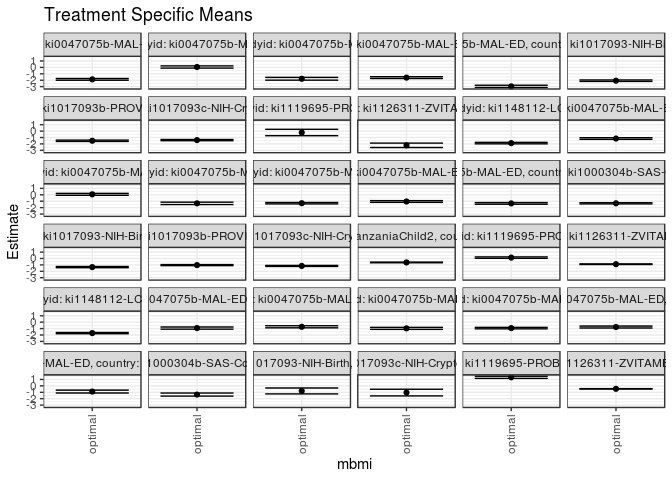

## Results Table

### Parameter: TSM

| agecat | studyid | country | intervention_level | baseline_level | estimate | ci_lower | ci_upper |
| --- | --- | --- | --- | --- | --- | --- | --- |
| Birth | ki0047075b-MAL-ED | BANGLADESH | optimal | observed | -0.9192104 | -1.0868009 | -0.7516199 |
| Birth | ki0047075b-MAL-ED | BRAZIL | optimal | observed | -0.7210052 | -0.8857770 | -0.5562335 |
| Birth | ki0047075b-MAL-ED | INDIA | optimal | observed | -0.9646004 | -1.1186065 | -0.8105942 |
| Birth | ki0047075b-MAL-ED | PERU | optimal | observed | -0.9241876 | -1.0376890 | -0.8106861 |
| Birth | ki0047075b-MAL-ED | SOUTH AFRICA | optimal | observed | -0.7574771 | -0.9084921 | -0.6064620 |
| Birth | ki0047075b-MAL-ED | TANZANIA, UNITED REPUBLIC OF | optimal | observed | -0.8870101 | -1.1106970 | -0.6633233 |
| Birth | ki1000304b-SAS-CompFeed | INDIA | optimal | observed | -1.3583856 | -1.5977658 | -1.1190055 |
| Birth | ki1017093-NIH-Birth | BANGLADESH | optimal | observed | -0.7928311 | -1.2540834 | -0.3315787 |
| Birth | ki1017093c-NIH-Crypto | BANGLADESH | optimal | observed | -1.0441625 | -1.5625644 | -0.5257606 |
| Birth | ki1119695-PROBIT | BELARUS | optimal | observed | 1.3362510 | 1.1716365 | 1.5008656 |
| Birth | ki1126311-ZVITAMBO | ZIMBABWE | optimal | observed | -0.4598483 | -0.4899048 | -0.4297919 |
| 6 months | ki0047075b-MAL-ED | BANGLADESH | optimal | observed | -1.1618902 | -1.2880793 | -1.0357011 |
| 6 months | ki0047075b-MAL-ED | BRAZIL | optimal | observed | 0.0743157 | -0.0747881 | 0.2234195 |
| 6 months | ki0047075b-MAL-ED | INDIA | optimal | observed | -1.3362232 | -1.5217162 | -1.1507303 |
| 6 months | ki0047075b-MAL-ED | PERU | optimal | observed | -1.3132541 | -1.4220049 | -1.2045034 |
| 6 months | ki0047075b-MAL-ED | SOUTH AFRICA | optimal | observed | -1.0465204 | -1.1776551 | -0.9153857 |
| 6 months | ki0047075b-MAL-ED | TANZANIA, UNITED REPUBLIC OF | optimal | observed | -1.3427583 | -1.4668365 | -1.2186801 |
| 6 months | ki1000304b-SAS-CompFeed | INDIA | optimal | observed | -1.3291537 | -1.4244882 | -1.2338191 |
| 6 months | ki1017093-NIH-Birth | BANGLADESH | optimal | observed | -1.3438170 | -1.4394641 | -1.2481698 |
| 6 months | ki1017093b-PROVIDE | BANGLADESH | optimal | observed | -1.0309730 | -1.1165099 | -0.9454361 |
| 6 months | ki1017093c-NIH-Crypto | BANGLADESH | optimal | observed | -1.1612175 | -1.2352981 | -1.0871369 |
| 6 months | ki1066203-TanzaniaChild2 | TANZANIA, UNITED REPUBLIC OF | optimal | observed | -0.6153463 | -0.6644883 | -0.5662044 |
| 6 months | ki1119695-PROBIT | BELARUS | optimal | observed | 0.1375558 | 0.0262440 | 0.2488676 |
| 6 months | ki1126311-ZVITAMBO | ZIMBABWE | optimal | observed | -0.8871595 | -0.9313871 | -0.8429319 |
| 6 months | ki1148112-LCNI-5 | MALAWI | optimal | observed | -1.7045439 | -1.7982282 | -1.6108596 |
| 24 months | ki0047075b-MAL-ED | BANGLADESH | optimal | observed | -1.8652648 | -1.9963165 | -1.7342132 |
| 24 months | ki0047075b-MAL-ED | BRAZIL | optimal | observed | 0.0637404 | -0.1047561 | 0.2322369 |
| 24 months | ki0047075b-MAL-ED | INDIA | optimal | observed | -1.7764718 | -1.9944032 | -1.5585404 |
| 24 months | ki0047075b-MAL-ED | SOUTH AFRICA | optimal | observed | -1.5916918 | -1.7299262 | -1.4534573 |
| 24 months | ki0047075b-MAL-ED | TANZANIA, UNITED REPUBLIC OF | optimal | observed | -2.9598351 | -3.1371494 | -2.7825207 |
| 24 months | ki1017093-NIH-Birth | BANGLADESH | optimal | observed | -2.0747088 | -2.1886233 | -1.9607943 |
| 24 months | ki1017093b-PROVIDE | BANGLADESH | optimal | observed | -1.5056640 | -1.6083090 | -1.4030190 |
| 24 months | ki1017093c-NIH-Crypto | BANGLADESH | optimal | observed | -1.4016822 | -1.4912904 | -1.3120739 |
| 24 months | ki1119695-PROBIT | BELARUS | optimal | observed | -0.2163119 | -0.7142286 | 0.2816048 |
| 24 months | ki1126311-ZVITAMBO | ZIMBABWE | optimal | observed | -2.2206005 | -2.5653707 | -1.8758303 |
| 24 months | ki1148112-LCNI-5 | MALAWI | optimal | observed | -1.8753879 | -1.9878490 | -1.7629269 |

### Parameter: E(Y)

| agecat | studyid | country | intervention_level | baseline_level | estimate | ci_lower | ci_upper |
| --- | --- | --- | --- | --- | --- | --- | --- |
| Birth | ki0047075b-MAL-ED | BANGLADESH | observed | observed | -1.0455285 | -1.1715695 | -0.9194875 |
| Birth | ki0047075b-MAL-ED | BRAZIL | observed | observed | -0.7397283 | -0.8996215 | -0.5798350 |
| Birth | ki0047075b-MAL-ED | INDIA | observed | observed | -1.0200505 | -1.1624932 | -0.8776078 |
| Birth | ki0047075b-MAL-ED | PERU | observed | observed | -0.9386232 | -1.0507144 | -0.8265319 |
| Birth | ki0047075b-MAL-ED | SOUTH AFRICA | observed | observed | -0.6921930 | -0.8218578 | -0.5625282 |
| Birth | ki0047075b-MAL-ED | TANZANIA, UNITED REPUBLIC OF | observed | observed | -0.9267769 | -1.1425813 | -0.7109724 |
| Birth | ki1000304b-SAS-CompFeed | INDIA | observed | observed | -1.4803846 | -1.6742160 | -1.2865532 |
| Birth | ki1017093-NIH-Birth | BANGLADESH | observed | observed | -0.5292857 | -0.8821252 | -0.1764462 |
| Birth | ki1017093c-NIH-Crypto | BANGLADESH | observed | observed | -1.1100000 | -1.5086894 | -0.7113106 |
| Birth | ki1119695-PROBIT | BELARUS | observed | observed | 1.3263412 | 1.1672322 | 1.4854501 |
| Birth | ki1126311-ZVITAMBO | ZIMBABWE | observed | observed | -0.4772566 | -0.5017796 | -0.4527336 |
| 6 months | ki0047075b-MAL-ED | BANGLADESH | observed | observed | -1.2056777 | -1.3231497 | -1.0882058 |
| 6 months | ki0047075b-MAL-ED | BRAZIL | observed | observed | 0.0532131 | -0.0914567 | 0.1978830 |
| 6 months | ki0047075b-MAL-ED | INDIA | observed | observed | -1.2148369 | -1.3332371 | -1.0964367 |
| 6 months | ki0047075b-MAL-ED | PERU | observed | observed | -1.3272488 | -1.4359649 | -1.2185326 |
| 6 months | ki0047075b-MAL-ED | SOUTH AFRICA | observed | observed | -1.0728012 | -1.2026830 | -0.9429194 |
| 6 months | ki0047075b-MAL-ED | TANZANIA, UNITED REPUBLIC OF | observed | observed | -1.3601215 | -1.4821830 | -1.2380600 |
| 6 months | ki1000304b-SAS-CompFeed | INDIA | observed | observed | -1.4072209 | -1.4983514 | -1.3160903 |
| 6 months | ki1017093-NIH-Birth | BANGLADESH | observed | observed | -1.4073821 | -1.4960598 | -1.3187043 |
| 6 months | ki1017093b-PROVIDE | BANGLADESH | observed | observed | -1.0848568 | -1.1613109 | -1.0084028 |
| 6 months | ki1017093c-NIH-Crypto | BANGLADESH | observed | observed | -1.1986783 | -1.2700937 | -1.1272630 |
| 6 months | ki1066203-TanzaniaChild2 | TANZANIA, UNITED REPUBLIC OF | observed | observed | -0.5405711 | -0.5899965 | -0.4911457 |
| 6 months | ki1119695-PROBIT | BELARUS | observed | observed | 0.1153731 | 0.0222128 | 0.2085334 |
| 6 months | ki1126311-ZVITAMBO | ZIMBABWE | observed | observed | -0.9008757 | -0.9285733 | -0.8731780 |
| 6 months | ki1148112-LCNI-5 | MALAWI | observed | observed | -1.6577751 | -1.7275296 | -1.5880207 |
| 24 months | ki0047075b-MAL-ED | BANGLADESH | observed | observed | -1.9431132 | -2.0691678 | -1.8170586 |
| 24 months | ki0047075b-MAL-ED | BRAZIL | observed | observed | 0.0418452 | -0.1263708 | 0.2100613 |
| 24 months | ki0047075b-MAL-ED | INDIA | observed | observed | -1.8439159 | -1.9704751 | -1.7173568 |
| 24 months | ki0047075b-MAL-ED | SOUTH AFRICA | observed | observed | -1.6220299 | -1.7590593 | -1.4850005 |
| 24 months | ki0047075b-MAL-ED | TANZANIA, UNITED REPUBLIC OF | observed | observed | -2.6058879 | -2.7403043 | -2.4714714 |
| 24 months | ki1017093-NIH-Birth | BANGLADESH | observed | observed | -2.1807945 | -2.2835902 | -2.0779987 |
| 24 months | ki1017093b-PROVIDE | BANGLADESH | observed | observed | -1.5839236 | -1.6672059 | -1.5006413 |
| 24 months | ki1017093c-NIH-Crypto | BANGLADESH | observed | observed | -1.4295331 | -1.5127726 | -1.3462935 |
| 24 months | ki1119695-PROBIT | BELARUS | observed | observed | -0.1322181 | -0.4300523 | 0.1656161 |
| 24 months | ki1126311-ZVITAMBO | ZIMBABWE | observed | observed | -2.4135279 | -2.5366872 | -2.2903685 |
| 24 months | ki1148112-LCNI-5 | MALAWI | observed | observed | -1.8744367 | -1.9556750 | -1.7931984 |

### Parameter: PAR

| agecat | studyid | country | intervention_level | baseline_level | estimate | ci_lower | ci_upper |
| --- | --- | --- | --- | --- | --- | --- | --- |
| Birth | ki0047075b-MAL-ED | BANGLADESH | optimal | observed | -0.1263181 | -0.2696308 | 0.0169946 |
| Birth | ki0047075b-MAL-ED | BRAZIL | optimal | observed | -0.0187230 | -0.0521145 | 0.0146685 |
| Birth | ki0047075b-MAL-ED | INDIA | optimal | observed | -0.0554502 | -0.1347867 | 0.0238864 |
| Birth | ki0047075b-MAL-ED | PERU | optimal | observed | -0.0144356 | -0.0327834 | 0.0039122 |
| Birth | ki0047075b-MAL-ED | SOUTH AFRICA | optimal | observed | 0.0652841 | -0.0146942 | 0.1452624 |
| Birth | ki0047075b-MAL-ED | TANZANIA, UNITED REPUBLIC OF | optimal | observed | -0.0397667 | -0.0867087 | 0.0071752 |
| Birth | ki1000304b-SAS-CompFeed | INDIA | optimal | observed | -0.1219990 | -0.3502992 | 0.1063012 |
| Birth | ki1017093-NIH-Birth | BANGLADESH | optimal | observed | 0.2635453 | -0.2417521 | 0.7688428 |
| Birth | ki1017093c-NIH-Crypto | BANGLADESH | optimal | observed | -0.0658375 | -0.2429757 | 0.1113008 |
| Birth | ki1119695-PROBIT | BELARUS | optimal | observed | -0.0099099 | -0.0433077 | 0.0234879 |
| Birth | ki1126311-ZVITAMBO | ZIMBABWE | optimal | observed | -0.0174083 | -0.0358530 | 0.0010364 |
| 6 months | ki0047075b-MAL-ED | BANGLADESH | optimal | observed | -0.0437876 | -0.0893553 | 0.0017801 |
| 6 months | ki0047075b-MAL-ED | BRAZIL | optimal | observed | -0.0211025 | -0.0460547 | 0.0038496 |
| 6 months | ki0047075b-MAL-ED | INDIA | optimal | observed | 0.1213864 | -0.0185061 | 0.2612789 |
| 6 months | ki0047075b-MAL-ED | PERU | optimal | observed | -0.0139946 | -0.0382928 | 0.0103035 |
| 6 months | ki0047075b-MAL-ED | SOUTH AFRICA | optimal | observed | -0.0262808 | -0.0520102 | -0.0005515 |
| 6 months | ki0047075b-MAL-ED | TANZANIA, UNITED REPUBLIC OF | optimal | observed | -0.0173632 | -0.0532847 | 0.0185584 |
| 6 months | ki1000304b-SAS-CompFeed | INDIA | optimal | observed | -0.0780672 | -0.1178212 | -0.0383132 |
| 6 months | ki1017093-NIH-Birth | BANGLADESH | optimal | observed | -0.0635651 | -0.1078571 | -0.0192731 |
| 6 months | ki1017093b-PROVIDE | BANGLADESH | optimal | observed | -0.0538838 | -0.0877782 | -0.0199895 |
| 6 months | ki1017093c-NIH-Crypto | BANGLADESH | optimal | observed | -0.0374609 | -0.0634684 | -0.0114533 |
| 6 months | ki1066203-TanzaniaChild2 | TANZANIA, UNITED REPUBLIC OF | optimal | observed | 0.0747752 | 0.0444072 | 0.1051433 |
| 6 months | ki1119695-PROBIT | BELARUS | optimal | observed | -0.0221827 | -0.0883079 | 0.0439425 |
| 6 months | ki1126311-ZVITAMBO | ZIMBABWE | optimal | observed | -0.0137162 | -0.0486670 | 0.0212347 |
| 6 months | ki1148112-LCNI-5 | MALAWI | optimal | observed | 0.0467688 | -0.0109080 | 0.1044456 |
| 24 months | ki0047075b-MAL-ED | BANGLADESH | optimal | observed | -0.0778484 | -0.1377715 | -0.0179253 |
| 24 months | ki0047075b-MAL-ED | BRAZIL | optimal | observed | -0.0218951 | -0.0665363 | 0.0227461 |
| 24 months | ki0047075b-MAL-ED | INDIA | optimal | observed | -0.0674442 | -0.2409283 | 0.1060400 |
| 24 months | ki0047075b-MAL-ED | SOUTH AFRICA | optimal | observed | -0.0303382 | -0.0589507 | -0.0017256 |
| 24 months | ki0047075b-MAL-ED | TANZANIA, UNITED REPUBLIC OF | optimal | observed | 0.3539472 | 0.1976646 | 0.5102298 |
| 24 months | ki1017093-NIH-Birth | BANGLADESH | optimal | observed | -0.1060857 | -0.1567689 | -0.0554026 |
| 24 months | ki1017093b-PROVIDE | BANGLADESH | optimal | observed | -0.0782596 | -0.1406078 | -0.0159114 |
| 24 months | ki1017093c-NIH-Crypto | BANGLADESH | optimal | observed | -0.0278509 | -0.0658555 | 0.0101537 |
| 24 months | ki1119695-PROBIT | BELARUS | optimal | observed | 0.0840938 | -0.3843621 | 0.5525497 |
| 24 months | ki1126311-ZVITAMBO | ZIMBABWE | optimal | observed | -0.1929273 | -0.5255412 | 0.1396866 |
| 24 months | ki1148112-LCNI-5 | MALAWI | optimal | observed | 0.0009512 | -0.0758479 | 0.0777502 |